# Selecting NCA slope points: deterministic algorithms versus an LLM

Jerry Hu

2026-11-04

← PK/PD Home Page

# 1 Summary

**Background.** Choosing the sampling times that define the terminal elimination phase is a routine NCA decision. This study compares the ability of deterministic algorithms and an LLM to select the points that define the distribution and terminal phases across a planned series of PK profiles, starting with an oral two-compartment profile.

**Methods.** Concentration–time data for 24 subjects were simulated from a two-compartment model with first-order oral absorption, between-subject variability and residual error (mrgsolve). Four approaches selected the points: the PKNCA best-fit rule, an LLM (Claude Opus 5.5) with a short prompt and R, a simple algorithm and a designed algorithm. A Best achievable reference used the true phase boundaries and half-lives to find, within the true phase windows, the selection closest to each subject’s true half-lives. One shared estimator computed t½,λz and t½,α from every selection. Each phase of each subject was scored correct or incorrect: correct if it was reported within ±20% of the true half-life where such a selection existed, or declined where none did.

**Results.** Over both phases, the designed algorithm made 83.3% correct decisions and the simple algorithm 66.7%. The LLM with the short prompt scored 62.5%. The best-fit rule, which selects the terminal phase only, scored 58.3% on that phase. All 95% intervals overlapped (24 subjects, one LLM run).

# 2 Background

Selecting the points that define the terminal rate constant (λz) is the standard example of a non-compartmental analysis (NCA) decision written as rules. PKNCA and Phoenix both codify a best-fit adjusted R² rule. It works profile by profile, has no rule for declining a poor fit by default, and does not address the distribution phase. A large language model (LLM) can now be asked to run an NCA end to end, including decisions like this one. Slope-point selection sits in between: it can be written as rules, yet analysts often judge it by eye.

The objective was to compare deterministic algorithms with an LLM at selecting the points that define the distribution and terminal phases.

# 3 Methods

## 3.1 Simulation

### 3.1.1 Model

Profiles were simulated from a two-compartment model with first-order absorption after a single 100 mg oral dose:

$$C(t) = A\,e^{-\alpha t} + B\,e^{-\beta
t} - (A + B)\,e^{-k_a t}$$

where $C(t)$ is the central concentration, $\alpha$ and $\beta$ are the distribution and terminal rate constants, $A$ and $B$ their macro-coefficients, and $k_a$ (ka) the absorption rate constant. Typical clearance (CL), central volume (V1), intercompartmental clearance (Q) and peripheral volume (V2) were 2.04 L/h, 10 L, 1.12 L/h and 15.3 L. These gave a terminal half-life t½,β of 16 h, the true value that t½,λz estimates, and a distribution half-life t½,α of 2.0 h (α/β 8). The terminal macro-fraction B/(A+B) was 0.1, and ka = 8α. Between-subject variability was log-normal, with coefficients of variation (CV) of 30% for CL, 25% for V1, 30% for Q, 25% for V2 and 20% for ka. A subject with ka/α < 3 was redrawn (2 redraws; lowest ka/α 4.87), so absorption never masked the distribution phase. Residual error was combined proportional (10%) and additive (standard deviation 0.0075 mg/L). Concentrations below the lower limit of quantification (LLOQ, 0.05 mg/L) were reported as below the limit (BLQ) and excluded from every fit.

### 3.1.2 Sampling design

Samples were drawn at 0, 0.25, 0.5, 1, 1.5, 2, 3, 4, 6, 8, 10, 12, 16, 24, 36, 48 and 72 h. 16 subjects had the full schedule and 8 a schedule truncated at 24 h, assigned at random. A truncated profile spans about one terminal half-life, so its terminal phase is usually not estimable.

### 3.1.3 True phase windows

Each subject’s truth came from its own parameters. The phase boundary $t_{eq} = \ln(A/B)/(\alpha - \beta)$ is the time at which the distribution and terminal terms are equal. The distribution window starts at $t_{abs5}$, the time after which the absorption term is below 5% of the distribution term. The true distribution window runs from $t_{abs5}$ to $t_{eq}$, and the true terminal window from $t_{eq}$ to the last quantifiable sample (Tlast).

The distribution term still contributes after $t_{eq}$: at 2·$t_{eq}$ the local half-life of a typical profile is still about 38% shorter than t½,λz. A terminal fit that starts at $t_{eq}$ therefore overestimates λz, so boundary accuracy and t½,λz accuracy can diverge.

A phase was **estimable** if at least one selection obeying the shared rules (below) put its half-life within ±20% of the subject’s true value. For the distribution phase, one (terminal, distribution) pair had to put both half-lives within ±20%, because t½,α is stripped against the reported terminal line. Every rule-valid selection was searched with the truth.

## 3.2 Approaches compared

Every approach returned the selected sample times only, per phase, or declined the phase. The LLM and both algorithms could use the whole set of 24 profiles to inform each subject’s selection.

[output not shown]

### 3.2.1 Best-fit rule

PKNCA 0.12.1 defaults. Candidate windows start at each sample after the time of peak concentration (Tmax) and end at Tlast (at least 3 points). Each window is fitted and fits with λz > 0 are kept. Of these, the fit with the highest adjusted R² and any within 0.0001 of it are selected, and the selected window with the most points wins. PKNCA takes the highest adjusted R² before removing fits with λz ≤ 0; this made no difference in any of the 24 profiles. The rule selects no distribution phase.

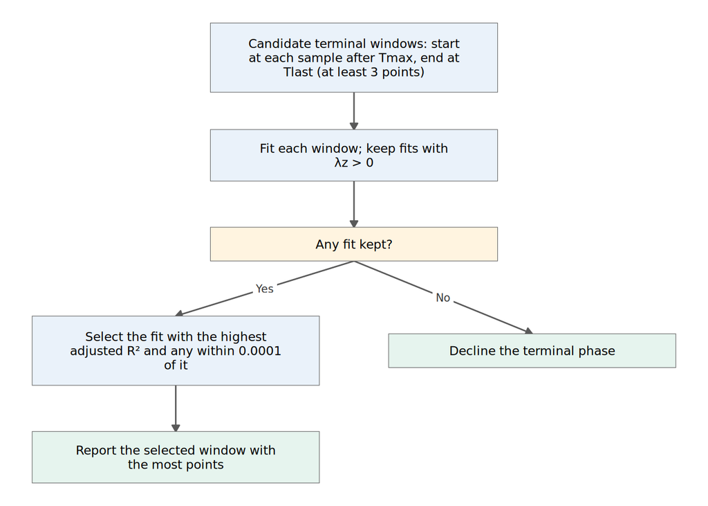

Best-fit rule (PKNCA 0.12.1 defaults), per profile.

### 3.2.2 LLM arms

There were two LLM arms: the LLM with a short prompt, and the LLM with a prompt and tools developed over multiple runs.

The developed arm is updated between scenarios (Section 3.4) and has no results in scenario 1. The short-prompt arm used Claude Opus 5.5 (medium thinking effort), in one call over all 24 subjects. It ran once, as an isolated, headless Claude Code session with R code execution confined to a folder holding only its inputs: the concentration–time table and a semi-log plot of every profile. It had no fitting tool, network or saved context. Its full user message follows.

```
You are given concentration–time data for 24 different subjects, all
receiving the same oral drug as a single dose: a table (`data.csv`, BLQ
marked) and a semi-log plot with one panel per subject (`profiles.png`).
For each subject, select the sample times that define the **distribution
phase** and the **terminal phase**, to be used for estimating t½,α and
t½,λz. If a phase cannot be reliably estimated for a subject, mark it not
estimable. Return only JSON in this schema:
`{"subject": 1, "distribution": {"times": [..]} | "not_estimable", "terminal": {"times": [..]} | "not_estimable", "note": "<one line>"}`

**Computing.** You can write and run R scripts in this folder
(`Rscript`). Use them for any calculation you need.

**Rules for every selection.**
1. A phase is one contiguous run of samples: every quantifiable sample
   between its first and last time is included; no single sample is
   dropped.
2. The terminal phase ends at the last quantifiable sample. BLQ samples are
   never selected.
3. Each phase has at least 3 samples, all after Tmax (Tmax itself
   excluded).
4. The distribution phase ends before the terminal phase starts; a gap
   between them is allowed.
5. Every distribution sample lies above the extrapolated terminal line
   (positive residual).
6. The terminal slope is negative, and the distribution slope is steeper
   than the terminal slope.
```

### 3.2.3 Simple algorithm

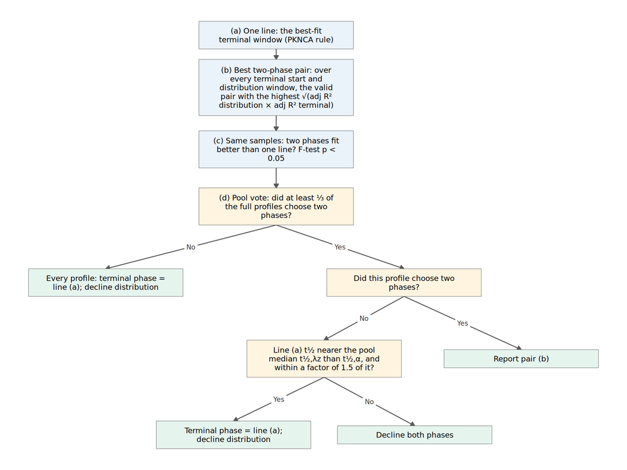

Simple algorithm. A profile with fewer than 3 samples after Tmax has both phases declined; a full profile is one sampled past 24 h.

### 3.2.4 Designed algorithm

The designed algorithm was built in an iterative LLM agentic loop on simulated development data from a wider population of drugs than this study, including monophasic drugs. In each round, designer agents (Claude Opus 5.5; five in round 1, three in round 2, two in round 3), each owning one candidate design, proposed or revised an algorithm as R code, starting from a draft by the author. Every candidate had to obey the six shared rules (Section 3.3), take every quantity from log-linear or stripping fits, state each rule in at most two plain sentences, and keep its pool-level steps deterministic. A failure-analysis agent then reviewed each leading candidate’s worst misses and proposed changes for the next round.

Candidates were scored by fixed R code, not by an agent. Each candidate first had to pass a check on noise-free copies of the data: no rule violations, and the distribution phase declined for monophasic drugs. Its score was then the percentage of correct decisions (Section 3.3) over both phases, on 1,000 simulated development datasets of 24 subjects each, with residual error. In each round, the simplest candidate (fewest rules and numeric thresholds) within 1 point of the best score was kept.

The loop was set to stop at 95% correct decisions or after 3 rounds. The author’s draft scored 64.7%, and the best round-3 candidate 79.4%. The loop stopped after round 3, to prevent over-fitting to the development data. A simpler round-3 candidate within 1 point of the best (78.6%) was kept and frozen. On a separate holdout set of 1,000 datasets it scored 77.6%. It never saw the scenario 1 data.

The frozen algorithm tests one line against two per profile, takes a majority vote across all profiles on the number of phases, and sets an earliest allowed terminal start from all profiles. It then chooses the terminal and distribution windows jointly, by smallest residual sum of squares over every sample after Tmax.

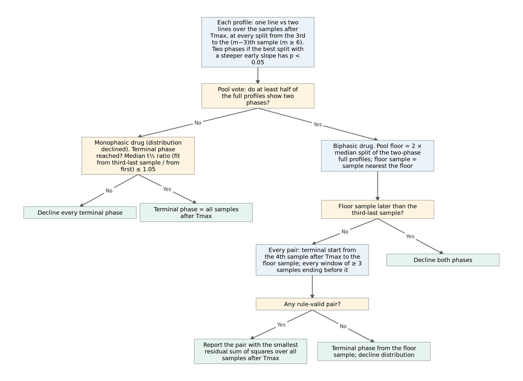

Designed algorithm. A profile with fewer than 3 samples after Tmax has both phases declined; a full profile is one sampled past 24 h.

### 3.2.5 Best achievable

A reference, not an approach a user could run. It knows each subject’s true phase boundaries and half-lives. The terminal window starts at or after $t_{eq}$; of these, the one with the smallest t½,λz error is its terminal line. The distribution window lies inside the true window ($t_{abs5}$ to $t_{eq}$); of these, stripped against that terminal line, the one with the smallest t½,α error is chosen. Each phase is reported if its error is within ±20% and declined otherwise, independently of the other phase, so a distribution phase can be reported without a terminal phase. For the other approaches, a distribution phase counts as estimable only if the same terminal samples also give t½,λz within ±20% (Section 3.1.3). Best achievable is scored per phase instead, so it is correct on every decision by construction. It shows how close a selection could get with the phase boundaries known.

## 3.3 Estimation and scoring

**Shared estimator.** One estimator was applied to every approach’s selection. A log-linear fit on the terminal points gave λz and t½,λz. Curve stripping on the distribution points, after subtracting the terminal line, gave α and t½,α. Differences between approaches therefore trace to point selection only.

**Shared rules.** Every selection had to obey six rules:

1. A phase is one contiguous run of samples; no quantifiable sample inside it is dropped.
2. The terminal phase ends at the last quantifiable sample; BLQ samples are never selected.
3. Each phase has at least 3 samples, all after Tmax.
4. The distribution phase ends before the terminal phase starts; a gap is allowed.
5. Every distribution sample lies above the extrapolated terminal line.
6. The terminal slope is negative, and the distribution slope is steeper than the terminal slope.

Departures in the LLM selections were counted.

**Outcome scoring.** For each profile and phase, the selection was scored as correct or incorrect:

- Correct: the phase was estimable, reported and within ±20% of the true half-life; or it was not estimable and declined.
- Incorrect: the phase was reported outside ±20%, reported when not estimable, or estimable and declined.

Two measures described how far the reported phases were from the truth and from the Best achievable selection:

- Relative error: (estimated − true)/true half-life.
- Boundary difference, in hours: each selected phase start and end minus the Best achievable selection’s, for subjects where both report the phase.

Both are summarised as median and interquartile range (IQR).

**Uncertainty.** Each approach’s results carry a 95% percentile bootstrap confidence interval (CI) from 2,000 resamples of subjects. The intervals show how precise each approach’s score is with 24 subjects. At this size, a proportion near 70% has a 95% interval of about ±18 percentage points.

## 3.4 Between-scenario analyses and updates

The study runs over a series of scenarios, each a new simulated dataset with different drug and sampling properties. After each scenario, its results are reviewed, and the LLM with the developed prompt and the designed algorithm may be updated. The best-fit rule, the LLM with the short prompt and the simple algorithm stay frozen as baselines. Every approach is run on each new scenario. Any update is fixed and dated before the next scenario’s results are read. This report covers scenario 1.

| Scenario | Drug | Sampling | Approaches | Results |
| --- | --- | --- | --- | --- |
| 1 | Oral two-compartment, fast absorption (ka ≫ α); t½,β 16 h, α/β 8 | 24 subjects: 16 sampled to 72 h, 8 truncated at 24 h | Best-fit rule, LLM with the short prompt, simple algorithm, designed algorithm, Best achievable | Section 4.1 |
| 2 | TBD | TBD | TBD | TBD |

# 4 Results

The results below follow the first scenario (Section 3.4).

## 4.1 Scenario 1

### 4.1.1 Simulated profiles

#### 4.1.1.1 Profiles

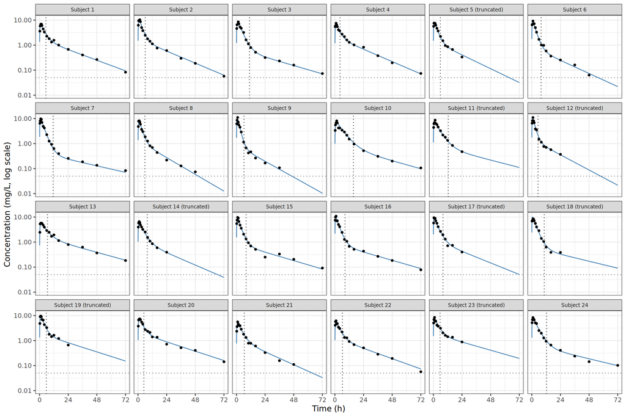

Observed concentrations by subject. Line: individual prediction without residual error. Dotted lines: true phase boundary (vertical) and LLOQ (horizontal).

#### 4.1.1.2 True values

The terminal phase was estimable in 18 of 24 subjects (16 full, 2 truncated). The distribution phase was estimable in the same 18 subjects. It counted as estimable only if the terminal phase was too: t½,α is calculated after subtracting the terminal line, so both half-lives had to fall within ±20% of the true values using the same terminal samples.

Individual true values and estimability, by sampling schedule

| Quantity | Full (to 72 h) | Truncated (to 24 h) | All |
| --- | --- | --- | --- |
| N | 16 | 8 | 24 |
| t½,α (h) | 2.11 (1.29–3.96) | 2.21 (1.36–3.26) | 2.16 (1.29–3.96) |
| t½,β (h) | 18.5 (10.8–27.7) | 17.7 (11.9–26.2) | 18.5 (10.8–27.7) |
| α/β | 8.27 (5.72–13.2) | 8.20 (5.90–11.9) | 8.27 (5.72–13.2) |
| ka/α | 8.50 (4.87–13.8) | 10.7 (5.36–14.3) | 9.26 (4.87–14.3) |
| True distribution start (h) | 1.36 (0.871–1.63) | 1.21 (0.727–1.71) | 1.26 (0.727–1.71) |
| True phase boundary (h) | 6.58 (4.34–15.5) | 6.81 (5.24–12.5) | 6.58 (4.34–15.5) |
| True distribution window (h) | 5.20 (2.98–14.2) | 5.58 (3.85–11.3) | 5.20 (2.98–14.2) |
| Tlast (h) | 72.00 (36.00–72.00) | 24.00 (24.00–24.00) | 60.00 (24.00–72.00) |
| Post-Tmax samples (n) | 12 (11–13) | 10 (9–11) | 12 (9–13) |
| Distribution phase estimable, n | 16 | 2 | 18 |
| Terminal phase estimable, n | 16 | 2 | 18 |

Median (min–max) of individual values; counts for estimability. Tlast = last quantifiable sample.

### 4.1.2 Correct decisions

The designed algorithm scored 83.3% (95% CI 68.8–95.8%) over both phases, and the simple algorithm 66.7% (95% CI 50.0–81.2%). The LLM with the short prompt scored 62.5% (95% CI 45.8–79.2%). On the terminal phase, the best-fit rule scored 58.3% (95% CI 37.5–79.2%).

Correct decisions over both phases, by approach

| Arm | Correct, n / N | Correct, % (95% CI) |
| --- | --- | --- |
| Best-fit (PKNCA) | – | – |
| LLM, short prompt | 30 / 48 | 62.5 (45.8, 79.2) |
| Simple algorithm | 32 / 48 | 66.7 (50.0, 81.2) |
| Designed algorithm | 40 / 48 | 83.3 (68.8, 95.8) |
| Best achievable | 48 / 48 | 100.0 (100.0, 100.0) |

Both phases combined: 48 subject-phases per approach. The best-fit rule selects no distribution phase; its terminal score is in the table below. Best achievable is scored on its own per-phase labels and is correct by construction (Section 3.2.5).

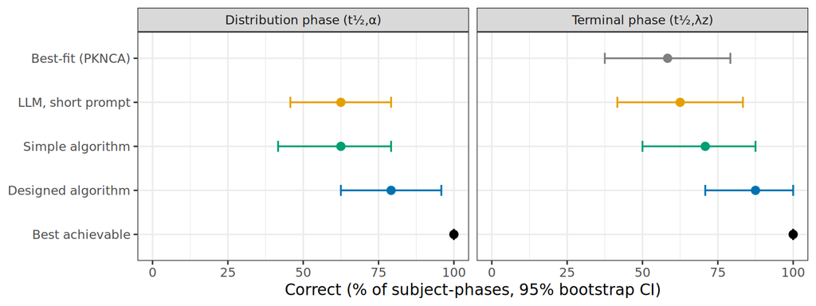

Correct decisions (%) with 95% bootstrap CI, by approach and phase. Best achievable is correct by construction.

Correct decisions and half-life error, by phase and approach

| Arm | Correct, % (95% CI) | Reported, n | Within ±20% of reported, % (95% CI) | Median error, % (IQR) | Reported, not estimable, n | Declined, estimable, n | Reported, outside ±20%, n |
| --- | --- | --- | --- | --- | --- | --- | --- |
| **Distribution phase (t½,α), N = 24** |  |  |  |  |  |  |  |
| Best-fit (PKNCA) | not estimated | not estimated | not estimated | not estimated | not estimated | not estimated | not estimated |
| LLM, short prompt | 62.5 (45.7, 79.2) | 22 | 81.8 (65.0, 95.7) | -6.7 (-14.5, 4.3) | 5 | 1 | 3 |
| Simple algorithm | 62.5 (41.7, 79.2) | 20 | 60.0 (36.8, 81.0) | -11.6 (-26.5, 1.9) | 2 | 0 | 7 |
| Designed algorithm | 79.2 (62.5, 95.8) | 15 | 86.7 (66.7, 100.0) | 0.7 (-3.8, 4.3) | 0 | 3 | 2 |
| Best achievable | 100.0 (100.0, 100.0) | 22 | 100.0 (100.0, 100.0) | -0.8 (-3.6, 1.4) | 0 | 0 | 0 |
| **Terminal phase (t½,λz), N = 24** |  |  |  |  |  |  |  |
| Best-fit (PKNCA) | 58.3 (37.5, 79.2) | 24 | 58.3 (37.5, 79.2) | -8.8 (-26.0, -1.2) | 6 | 0 | 4 |
| LLM, short prompt | 62.5 (41.7, 83.3) | 22 | 63.6 (43.5, 82.6) | -7.9 (-21.9, -1.8) | 5 | 1 | 3 |
| Simple algorithm | 70.8 (50.0, 87.5) | 21 | 66.7 (45.0, 85.7) | -7.0 (-12.4, -0.6) | 3 | 0 | 4 |
| Designed algorithm | 87.5 (70.8, 100.0) | 15 | 100.0 (100.0, 100.0) | -4.1 (-6.6, 5.7) | 0 | 3 | 0 |
| Best achievable | 100.0 (100.0, 100.0) | 18 | 100.0 (100.0, 100.0) | -4.7 (-7.2, -2.1) | 0 | 0 | 0 |

Median error and share within ±20% are over reported phases only. The best-fit rule selects no distribution phase. Best achievable is scored on its own per-phase labels (Section 3.2) and is correct by construction.

### 4.1.3 Half-life error

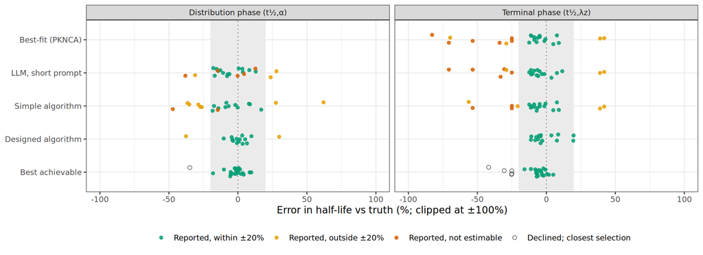

Individual half-life error vs truth, by approach and phase. Shaded band: ±20%. Hollow points: Best achievable’s closest selection for a phase it declines.

### 4.1.4 Phase boundaries

Phase boundaries relative to Best achievable, by approach

| Arm | Median (IQR) difference from Best achievable, h Distribution start | Median (IQR) difference from Best achievable, h Distribution end | Median (IQR) difference from Best achievable, h Terminal start | Median (IQR) difference from Best achievable, h Terminal end |
| --- | --- | --- | --- | --- |
| Best-fit (PKNCA) | – | – | -4.0 (-8.0, 7.0); n = 18 | 0.0 (0.0, 0.0); n = 18 |
| LLM, short prompt | 0.0 (-0.5, 0.0); n = 20 | 2.0 (0.0, 2.0); n = 20 | -4.0 (-12.0, 2.0); n = 17 | 0.0 (0.0, 0.0); n = 17 |
| Simple algorithm | 1.5 (0.0, 2.0); n = 19 | 2.0 (0.0, 4.0); n = 19 | -4.0 (-7.5, 7.0); n = 18 | 0.0 (0.0, 0.0); n = 18 |
| Designed algorithm | 0.0 (-0.4, 0.0); n = 14 | 4.0 (2.0, 6.0); n = 14 | 0.0 (-12.0, 3.0); n = 15 | 0.0 (0.0, 0.0); n = 15 |

Selected time minus Best achievable’s, over the n subjects where both report the phase. Positive: later than Best achievable.

### 4.1.5 Subject-level decisions

#### 4.1.5.1 Outcome by subject

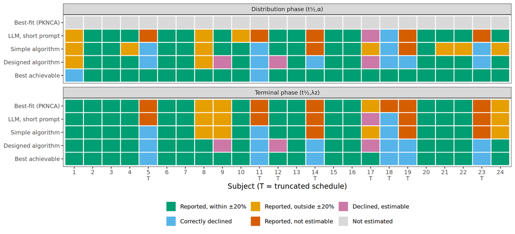

Decision outcome by subject, approach and phase.

#### 4.1.5.2 Selected samples

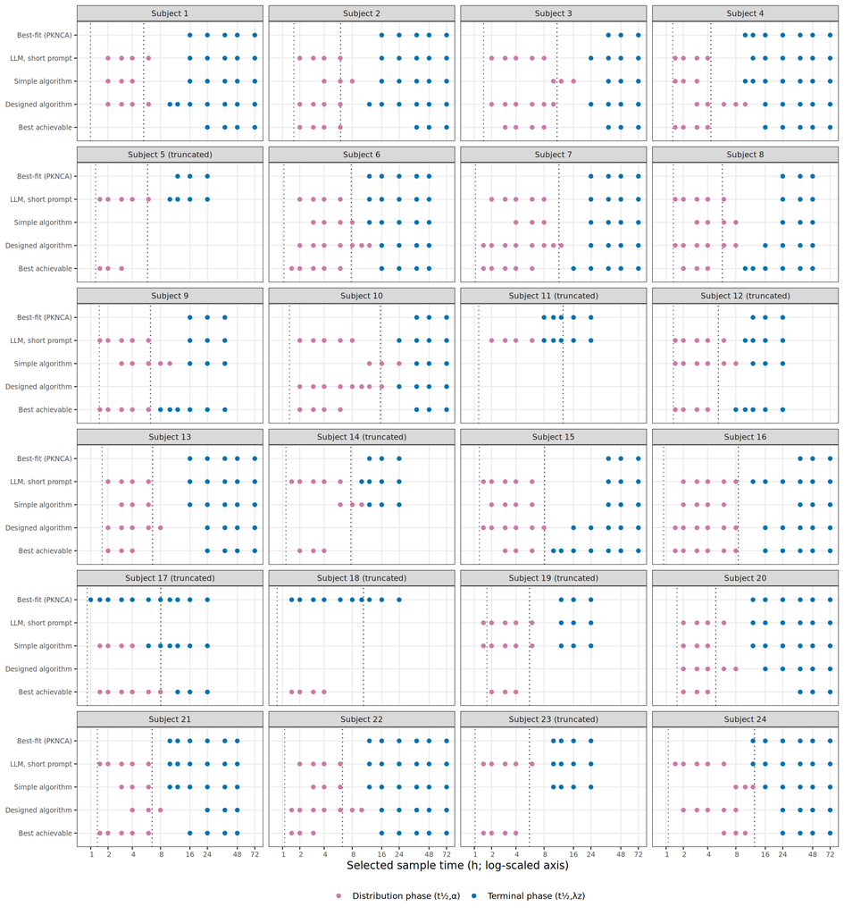

Selected sample times by subject and approach. Dotted lines: true distribution start (left) and true phase boundary (right).

#### 4.1.5.3 Listing

Selections and half-life errors, by subject and approach

| Subject | Schedule | True start (h) | True boundary (h) | Arm | Distribution window, h (n samples) | t½,α error (%) | Terminal window, h (n samples) | t½,λz error (%) |
| --- | --- | --- | --- | --- | --- | --- | --- | --- |
| 1 | full | 0.985 | 5.33 | Best-fit (PKNCA) | not estimated | – | 16–72 h (5) | -7.0 |
|  |  |  |  | LLM, short prompt | 2–6 h (4) | -31.0 | 16–72 h (5) | -7.0 |
|  |  |  |  | Simple algorithm | 2–4 h (3) | -35.2 | 16–72 h (5) | -7.0 |
|  |  |  |  | Designed algorithm | 2–6 h (4) | -37.6 | 10–72 h (7) | -10.9 |
|  |  |  |  | Best achievable | declined | – | 24–72 h (4) | -6.6 |
| 2 |  | 1.63 | 6.04 | Best-fit (PKNCA) | not estimated | – | 16–72 h (5) | -1.4 |
|  |  |  |  | LLM, short prompt | 2–6 h (4) | -7.4 | 16–72 h (5) | -1.4 |
|  |  |  |  | Simple algorithm | 4–8 h (3) | 16.9 | 16–72 h (5) | -1.4 |
|  |  |  |  | Designed algorithm | 2–6 h (4) | -10.3 | 12–72 h (6) | -4.1 |
|  |  |  |  | Best achievable | 2–6 h (4) | -5.2 | 36–72 h (3) | 0.3 |
| 3 |  | 1.51 | 10.9 | Best-fit (PKNCA) | not estimated | – | 36–72 h (3) | -0.6 |
|  |  |  |  | LLM, short prompt | 2–8 h (5) | 3.6 | 24–72 h (4) | 3.7 |
|  |  |  |  | Simple algorithm | 10–16 h (3) | -14.1 | 36–72 h (3) | -0.6 |
|  |  |  |  | Designed algorithm | 2–10 h (6) | -0.9 | 24–72 h (4) | 3.7 |
|  |  |  |  | Best achievable | 3–8 h (4) | -1.3 | 36–72 h (3) | -0.6 |
| 4 |  | 1.35 | 4.34 | Best-fit (PKNCA) | not estimated | – | 10–72 h (7) | -4.8 |
|  |  |  |  | LLM, short prompt | 1.5–4 h (4) | 3.3 | 12–72 h (6) | -3.2 |
|  |  |  |  | Simple algorithm | 1.5–3 h (3) | -26.3 | 10–72 h (7) | -4.8 |
|  |  |  |  | Designed algorithm | 3–10 h (5) | 9.8 | 16–72 h (5) | -2.9 |
|  |  |  |  | Best achievable | 1.5–4 h (4) | 3.6 | 16–72 h (5) | -2.9 |
| 5 | truncated | 1.26 | 5.86 | Best-fit (PKNCA) | not estimated | – | 12–24 h (3) | -33.9 |
|  |  |  |  | LLM, short prompt | 1.5–6 h (5) | -0.2 | 10–24 h (4) | -30.5 |
|  |  |  |  | Simple algorithm | declined | – | declined | – |
|  |  |  |  | Designed algorithm | declined | – | declined | – |
|  |  |  |  | Best achievable | 1.5–3 h (3) | 0.7 | declined | – |
| 6 | full | 1.08 | 7.81 | Best-fit (PKNCA) | not estimated | – | 12–48 h (5) | -11.0 |
|  |  |  |  | LLM, short prompt | 2–6 h (4) | -15.5 | 12–48 h (5) | -11.0 |
|  |  |  |  | Simple algorithm | 3–8 h (4) | -18.4 | 12–48 h (5) | -11.0 |
|  |  |  |  | Designed algorithm | 2–12 h (7) | 3.4 | 16–48 h (4) | -5.4 |
|  |  |  |  | Best achievable | 1.5–6 h (5) | -5.2 | 16–48 h (4) | -5.4 |

[output cut: 90 more lines]

### 4.1.6 LLM runs

#### 4.1.6.1 Rule compliance

Subjects departing from each shared rule, by approach

| Arm | Rule 1 | Rule 2 | Rule 3 | Rule 4 | Rule 5 | Rule 6 | Subjects with any violation, n |
| --- | --- | --- | --- | --- | --- | --- | --- |
| Best-fit (PKNCA) | 0 | 0 | 0 | 0 | 0 | 0 | 0 |
| LLM, short prompt | 0 | 0 | 0 | 0 | 0 | 0 | 0 |
| Simple algorithm | 0 | 0 | 0 | 0 | 0 | 0 | 0 |
| Designed algorithm | 0 | 0 | 0 | 0 | 0 | 0 | 0 |
| Best achievable | 0 | 0 | 0 | 0 | 0 | 0 | 0 |

#### 4.1.6.2 Token use

Token use and run time of the LLM run

| Arm | Output tokens (incl. thinking) | Input tokens | Cache read tokens | Cache write tokens | Tool calls | Duration (s) |
| --- | --- | --- | --- | --- | --- | --- |
| LLM, short prompt | 6,746 | 14 | 71,968 | 20,584 | 8 (Bash 4, Read 2, Write 2) | 67 |

One run. Counts include a fixed system prompt and tool definitions, identical across arms.

#### 4.1.6.3 Agreement

Share of subjects (%) on which two approaches made the same report-or-decline decision.

Distribution phase

| Arm | LLM, short prompt | Simple algorithm | Designed algorithm | Best achievable |
| --- | --- | --- | --- | --- |
| LLM, short prompt | 100.0 | 83.3 | 70.8 | 83.3 |
| Simple algorithm | 83.3 | 100.0 | 79.2 | 83.3 |
| Designed algorithm | 70.8 | 79.2 | 100.0 | 62.5 |
| Best achievable | 83.3 | 83.3 | 62.5 | 100.0 |

Terminal phase

| Arm | Best-fit (PKNCA) | LLM, short prompt | Simple algorithm | Designed algorithm | Best achievable |
| --- | --- | --- | --- | --- | --- |
| Best-fit (PKNCA) | 100.0 | 91.7 | 87.5 | 62.5 | 75.0 |
| LLM, short prompt | 91.7 | 100.0 | 87.5 | 70.8 | 75.0 |
| Simple algorithm | 87.5 | 87.5 | 100.0 | 75.0 | 87.5 |
| Designed algorithm | 62.5 | 70.8 | 75.0 | 100.0 | 87.5 |
| Best achievable | 75.0 | 75.0 | 87.5 | 87.5 | 100.0 |

#### 4.1.6.4 Notes returned

Notes returned by the LLM, by subject

| Arm | Subject | Note returned by the LLM |
| --- | --- | --- |
| LLM, short prompt | 1 | Clear biexponential decline; t½,λz ≈ 15.8 h, adj R² 0.997. |
| LLM, short prompt | 2 | Clear biexponential decline; t½,λz ≈ 14.8 h, adj R² 0.994. |
| LLM, short prompt | 3 | Sharp bend near 10–16 h; t½,λz ≈ 22.5 h. |
| LLM, short prompt | 4 | Terminal phase uses 6 points, adj R² 0.991; t½,λz ≈ 14.2 h. |
| LLM, short prompt | 5 | Sampling stops at 24 h, so the terminal phase is short; t½,λz ≈ 9.1 h. |
| LLM, short prompt | 6 | 72 h sample is BLQ; t½,λz ≈ 12.2 h. |
| LLM, short prompt | 7 | Long, flat terminal phase; t½,λz ≈ 29.8 h. |
| LLM, short prompt | 8 | 72 h sample is BLQ; the curve still bends until 24 h, so only 3 terminal points; t½,λz ≈ 15.3 h. |
| LLM, short prompt | 9 | 48 and 72 h samples are BLQ; the 12 h point rises above 10 h, so terminal starts at 16 h; t½,λz ≈ 15.8 h. |
| LLM, short prompt | 10 | Plateau at 3–4 h makes the distribution slope shallower (t½,α ≈ 5.9 h); t½,λz ≈ 21.3 h. |
| LLM, short prompt | 11 | Sampling stops at 24 h and the two phases are poorly separated (t½,α ≈ 4 h vs t½,λz ≈ 7.2 h). |
| LLM, short prompt | 12 | Sampling stops at 24 h; terminal fit adj R² 0.999; t½,λz ≈ 13.3 h. |
| LLM, short prompt | 13 | Terminal starts after the 12 h bump; t½,λz ≈ 21.4 h. |
| LLM, short prompt | 14 | Sampling stops at 24 h; t½,λz ≈ 9.8 h, adj R² 0.95. |
| LLM, short prompt | 15 | The 24 h sample is out of line (lower than 36 h), so terminal starts at 36 h; t½,λz ≈ 19.6 h. |
| LLM, short prompt | 16 | Consistent terminal line from 12 h; t½,λz ≈ 19.8 h. |
| LLM, short prompt | 17 | Sampling stops at 24 h and 12–16 h is non-decreasing; no fit has adj R² above 0.87, so the phases cannot be separated. |
| LLM, short prompt | 18 | 16 and 24 h are flat (0.387 vs 0.384 mg/L) and late fits are poor, so the phases cannot be separated. |
| LLM, short prompt | 19 | Rebound at 12 h and sampling stops at 24 h; the terminal span is short (≈1.3 half-lives), so t½,λz ≈ 9.2 h is weak. |
| LLM, short prompt | 20 | Some scatter at 8–16 h; t½,λz ≈ 18.5 h, adj R² 0.972. |
| LLM, short prompt | 21 | 72 h sample is BLQ; t½,λz ≈ 12.5 h, adj R² 0.975. |
| LLM, short prompt | 22 | The 1.5 h dip is left out of the distribution phase; t½,λz ≈ 15.4 h, adj R² 0.995. |
| LLM, short prompt | 23 | Sampling stops at 24 h and 12–16 h is nearly flat; t½,λz ≈ 16.6 h is uncertain. |
| LLM, short prompt | 24 | The curve flattens at 72 h and the terminal fit is only moderate (adj R² 0.905); t½,λz ≈ 18.7 h. |

# 5 Discussion

**Correct decisions.** The designed algorithm made the most correct decisions (83.3% over both phases), followed by the simple algorithm (66.7%) and the LLM with the short prompt (62.5%); on the terminal phase the best-fit rule scored 58.3%. The intervals overlap, so with 24 subjects the order is an estimate, not a ranking.

**Where the points were lost.** On the truncated profiles, the usual error was reporting a phase that was not estimable; on the full profiles, it was a half-life outside ±20%. The best-fit rule lost most of its points on the truncated profiles (7 of 10 errors), and so did the LLM (12 of 18). The best-fit rule reported a terminal phase in all 24 subjects, including 6 where none was estimable. The LLM reported 5 of those and made the same report-or-decline decision as the best-fit rule in 91.7% of subjects. Its notes mentioned the short sampling for each of those 5 subjects, and all but one flagged the estimate as uncertain (for example, “sampling stops at 24 h, so the terminal phase is short”). It reported the phase anyway: it was given no rule for declining. The designed algorithm reported no phase that was not estimable, at the cost of declining 3 terminal and 3 distribution phases that were. Every terminal phase it reported was within ±20%.

**What was achievable.** With the phase boundaries known, the closest terminal window in 5 truncated subjects still missed the true t½,λz by 25–42%. Declining these is correct. The designed algorithm’s median terminal start matched Best achievable’s (median difference 0 h, IQR -12.0 to 3.0 h); the best-fit rule, the LLM and the simple algorithm started it a median 4 h earlier, where the distribution term still contributes.

**Implication.** When slope selection is written as rules, a deterministic algorithm applies them the same way to every profile and can carry an explicit decline rule, which is where the LLM and the best-fit rule lost most points here. Given a short prompt, the LLM behaved much like the best-fit rule with a distribution phase added. Whether a prompt and tools developed over runs close that gap is the question for the next scenario.

**Reference choices.** The comparison with the best-fit rule is not neutral. Both algorithms were developed against simulated truth from this model family, while PKNCA’s rule was not. Best achievable uses the true phase boundaries and half-lives, so it shows what a selection could reach with them known; no user could run it.

**Limitations.**

- **One LLM run.** Run-to-run variation is not estimable, so any difference involving the LLM carries unmeasured uncertainty.
- **One drug, one model family.** Fast absorption (ka ≫ α) only; absorption masking and flip-flop kinetics were not studied. Later scenarios vary the drug and sampling properties.
- **24 subjects.** Bootstrap intervals over subjects are wide, as the tables show.
- **Joint distribution label.** A distribution phase counted as estimable only if the same terminal samples also gave t½,λz within ±20%, so no approach was credited for t½,α on a profile whose terminal phase failed. Best achievable was scored per phase.
- **Reference added after results.** Best achievable replaced a planned LLM arm given the true phase boundaries; the change was made after the study results were read.
- **No human analyst.** Analyst selection by eye was not compared.